# EDA Frequncy of Water peril claims in CovA. Distribution

```r
dataset <- read.csv("C:\\Kate\\Research\\Property\\Data\\property_water_claims_non_cat_fs_v5.csv", header=TRUE)
```

```r
library(vcd)
```

```r
library(ggplot2)
library(fitdistrplus)
colnames(dataset)
```

```
##   [1] "modeldata_id"
##   [2] "systemidstart"
##   [3] "systemidend"
##   [4] "cal_year"
##   [5] "startdate"
##   [6] "enddate"
##   [7] "startdatetm"
##   [8] "enddatetm"
##   [9] "ecy"
##  [10] "log_ecy"
##  [11] "policynumber"
##  [12] "policy_uniqueid"
##  [13] "policyterm"
##  [14] "policytype"
##  [15] "effectivedate"
```

[output cut: 87 more lines]

## Quick Overview

```r
str(dataset)
```

```
## 'data.frame':    1995765 obs. of  102 variables:
##  $ modeldata_id                       : int  534254 1793227 880091 1653118 353309 1289956 305141 1115709 2075469 1924235 ...
##  $ systemidstart                      : int  1219556 7403270 2370713 6514641 733342 4348409 544662 3436984 8943949 8072132 ...
##  $ systemidend                        : int  1219556 7403270 2955483 6514641 733342 4348409 544662 3436984 8943949 8072132 ...
##  $ cal_year                           : int  2013 2018 2014 2018 2011 2016 2012 2015 2020 2020 ...
##  $ startdate                          : Factor w/ 4290 levels "2009-01-01","2009-01-02",..: 1462 3611 2067 3424 1030 2878 1096 2544 4093 4018 ...
##  $ enddate                            : Factor w/ 4620 levels "2009-01-09","2009-01-12",..: 1553 3620 2159 3431 1044 2890 1225 2524 4351 4156 ...
##  $ startdatetm                        : Factor w/ 23752 levels "2008-01-09 00:00:00",..: 6832 20120 11523 19086 5616 15738 4639 13893 22823 21287 ...
##  $ enddatetm                          : Factor w/ 16484 levels "2009-01-09 00:00:00",..: 5396 14951 8350 12631 3384 11614 4105 10088 16289 15885 ...
##  $ ecy                                : num  0.339 0.115 0.342 0.11 0.129 ...
##  $ log_ecy                            : num  -1.08 -2.16 -1.07 -2.21 -2.05 ...
##  $ policynumber                       : Factor w/ 247043 levels "AZF0082147","AZF0221975",..: 33600 194123 187155 140475 2424 15381 185108 164391 100140 201424 ...
##  $ policy_uniqueid                    : int  445056 1541369 786905 1427784 348649 1124000 292060 976554 1776548 1654555 ...
##  $ policyterm                         : int  4 7 4 10 1 3 1 7 4 6 ...
##  $ policytype                         : Factor w/ 2 levels "New","Renewal": 2 2 2 2 1 2 1 2 2 2 ...
```

[output cut: 86 more lines]

```r
summary(dataset)
```

```
##   modeldata_id     systemidstart      systemidend         cal_year
##  Min.   :      1   Min.   :      2   Min.   :      3   Min.   :2009
##  1st Qu.: 546307   1st Qu.:1254638   1st Qu.:1353054   1st Qu.:2013
##  Median :1095214   Median :3292474   Median :3445261   Median :2016
##  Mean   :1091473   Mean   :3892680   Mean   :3993420   Mean   :2015
##  3rd Qu.:1637953   3rd Qu.:6415028   3rd Qu.:6591991   3rd Qu.:2018
##  Max.   :2178777   Max.   :9657386   Max.   :9657502   Max.   :2021
##
##       startdate             enddate                     startdatetm
##  2019-01-01: 113586   2019-01-01: 113557   2018-06-01 00:00:00:   1707
##  2018-01-01: 108834   2018-01-01: 108763   2017-09-01 00:00:00:   1557
##  2020-01-01:  96907   2020-01-01:  96974   2018-07-01 00:00:00:   1547
##  2017-01-01:  88488   2017-01-01:  88375   2017-07-01 00:00:00:   1508
##  2016-01-01:  76458   2016-01-01:  76444   2018-08-01 00:00:00:   1454
##  2013-01-01:  74669   2013-01-01:  74678   2018-09-01 00:00:00:   1435
##  (Other)   :1436823   (Other)   :1436974   (Other)            :1986557
##                enddatetm            ecy            log_ecy
##  2019-06-01 00:00:00:   2013   Min.   :0.0027   Min.   :-5.914504
##  2018-06-01 00:00:00:   1893   1st Qu.:0.2464   1st Qu.:-1.400799
##  2019-07-01 00:00:00:   1887   Median :0.4709   Median :-0.753110
##  2019-08-01 00:00:00:   1842   Mean   :0.4793   Mean   :-1.021357
##  2018-07-01 00:00:00:   1829   3rd Qu.:0.7091   3rd Qu.:-0.343759
##  2018-09-01 00:00:00:   1802   Max.   :1.0020   Max.   : 0.001998
##  (Other)            :1984499
##      policynumber     policy_uniqueid     policyterm       policytype
##  CAF0389924:    201   Min.   :      1   Min.   : 1.000   New    : 478819
##  CAF0461789:    192   1st Qu.: 494781   1st Qu.: 2.000   Renewal:1516946
##  CAF0475516:    168   Median : 959846   Median : 3.000
##  CAF0464778:    144   Mean   : 946658   Mean   : 3.792
##  CAF0393082:    130   3rd Qu.:1411214   3rd Qu.: 5.000
##  CAF0468201:    120   Max.   :1854593   Max.   :13.000
##  (Other)   :1994810
##     effectivedate        expirationdate    policystate
##  2018-06-01:   2058   2019-06-01:   2058   AZ: 149213
##  2017-07-01:   1945   2018-07-01:   1943   CA:1779623
##  2017-09-01:   1923   2018-09-01:   1923   NV:  66929
##  2018-07-01:   1914   2019-07-01:   1913
##  2017-06-01:   1901   2018-06-01:   1904
##  2018-08-01:   1898   2019-08-01:   1892
##  (Other)   :1984126   (Other)   :1984132
```

[output cut: 201 more lines]

```
##  2020-08-07 08:09:37.497:1995765   Min.   :  1.00
##                                    1st Qu.:  1.00
##                                    Median :  1.00
##                                    Mean   :  1.76
##                                    3rd Qu.:  1.00
##                                    Max.   :147.00
##
##  customer_cnt_active_policies_binned
##  Min.   :  1.000
##  1st Qu.:  1.000
##  Median :  1.000
##  Mean   :  2.939
##  3rd Qu.:  1.000
##  Max.   :150.000
##
```

## Number of Claims - Poisson Distribution

We can use goodfit() from vcd package. H0: The process is a Poisson process.

```r
gf = goodfit(dataset$cova_ic_nc_water,type= "poisson",method= "ML")
summary(gf)
```

```
##
##   Goodness-of-fit test for poisson distribution
##
##                      X^2 df      P(> X^2)
## Likelihood Ratio 630.459  2 1.251885e-137
```

Plot

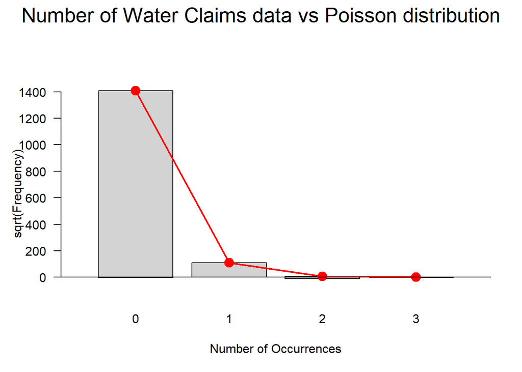

```r
plot(gf,main="Number of Water Claims data vs Poisson distribution")
```

P-Value

```r
gf.summary = capture.output(summary(gf))[[5]]
pvalue = unlist(strsplit(gf.summary, split = " "))
pvalue = as.numeric(pvalue[length(pvalue)])
pvalue
```

```
## [1] 1.251885e-137
```

P-Value is less then 0.05 and we can reject H0

It is not a Poisson distribution

## Number of Claims - Negative Binomial Distribution

```r
gf = goodfit(dataset$cova_ic_nc_water,type= "nbinomial",method= "ML")
summary(gf)
```

```
##
##   Goodness-of-fit test for nbinomial distribution
##
##                       X^2 df  P(> X^2)
## Likelihood Ratio 1.767831  1 0.1836508
```

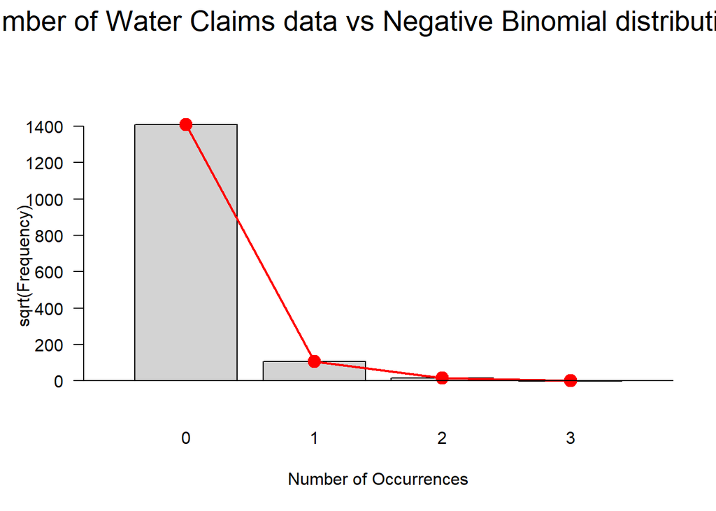

```r
plot(gf,main="Number of Water Claims data vs Negative Binomial distribution")
```

```r
gf.summary = capture.output(summary(gf))[[5]]
pvalue = unlist(strsplit(gf.summary, split = " "))
pvalue = as.numeric(pvalue[length(pvalue)])
pvalue
```

```
## [1] 0.1836508
```

P-Value is larger then 0.05 and we can not reject H0 The distribution is closer to negative binomial

## Incurred Losses

```r
data <- read.csv("C:\\Kate\\Research\\Property\\Data\\property_water_claims_non_cat_fs_v5.csv", header=TRUE)
```

Positive Losses only

```r
dataset <- data[data$cova_il_nc_water>=100,]
```

And removing long tail of large losses which is better to Gamma distribution but worse for normal log of losses

```r
dataset <- dataset[dataset$cova_il_nc_water<quantile(dataset$cova_il_nc_water, 0.95),]
```

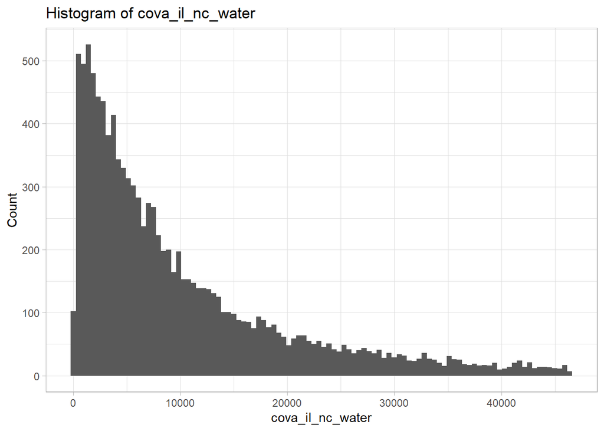

```r
ggplot(dataset, aes(x = .data[['cova_il_nc_water']])) +
  geom_histogram(bins=100) +
  labs(x = 'cova_il_nc_water', y = 'Count', title = paste("Histogram of", 'cova_il_nc_water'))+
  theme_light()
```

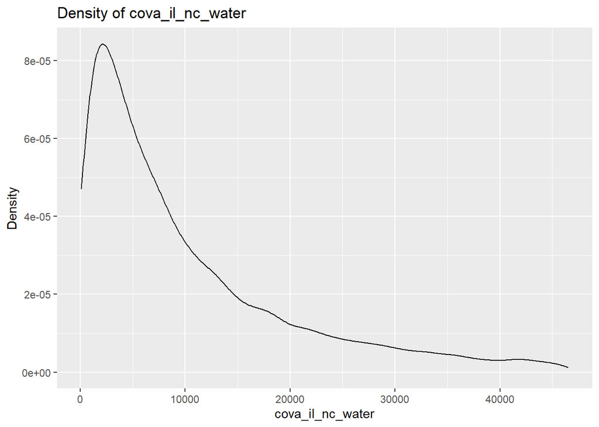

```r
ggplot(dataset, aes(x = .data[['cova_il_nc_water']])) +
  geom_density() +
  labs(x = 'cova_il_nc_water', y = 'Density', title = paste("Density of", 'cova_il_nc_water'))
```

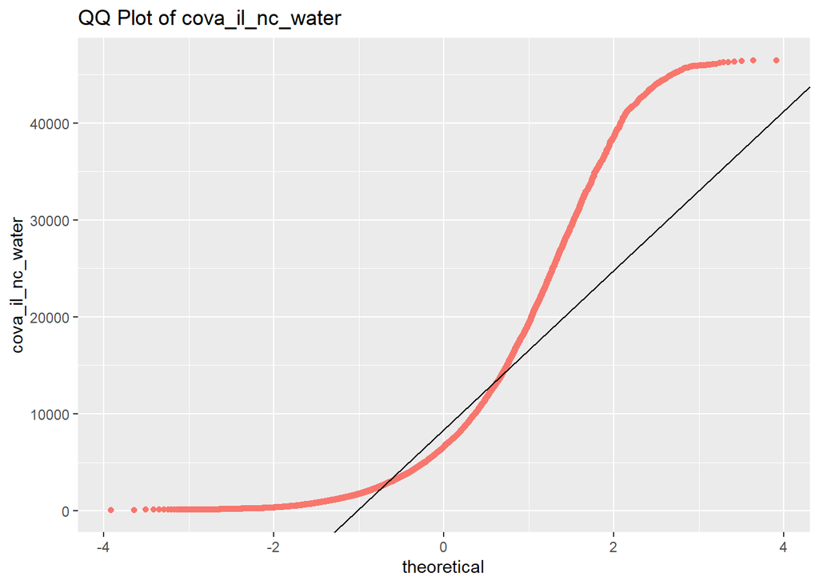

```r
  vec <- dataset$cova_il_nc_water
  y <- quantile(vec[!is.na(vec)], c(0.25, 0.75))
  x <- qnorm(c(0.25, 0.75))
  slope <- diff(y)/diff(x)
  int <- y[1L] - slope * x[1L]

ggplot(dataset, aes(sample = .data[['cova_il_nc_water']], col='red')) +
  stat_qq() +
  geom_abline(slope = slope, intercept = int) +
  theme(legend.position = "none") +
  labs(y = 'cova_il_nc_water', title = paste("QQ Plot of", 'cova_il_nc_water'))
```

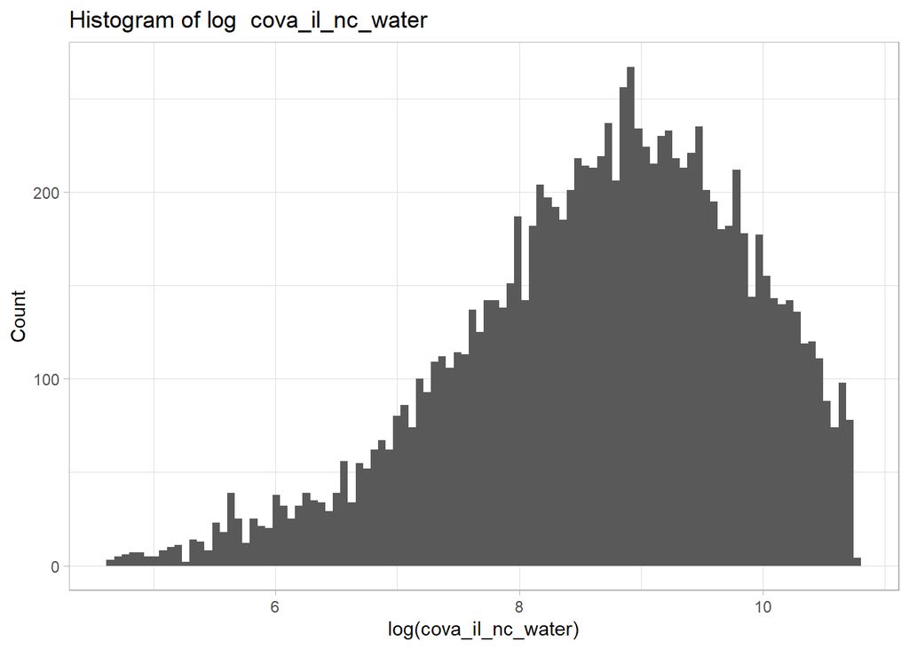

```r
ggplot(dataset, aes(x = .data[['log_cova_il_nc_water']])) +
  geom_histogram(bins=100) +
  labs(x = 'log(cova_il_nc_water)', y = 'Count', title = paste("Histogram of log ", 'cova_il_nc_water'))+
  theme_light()
```

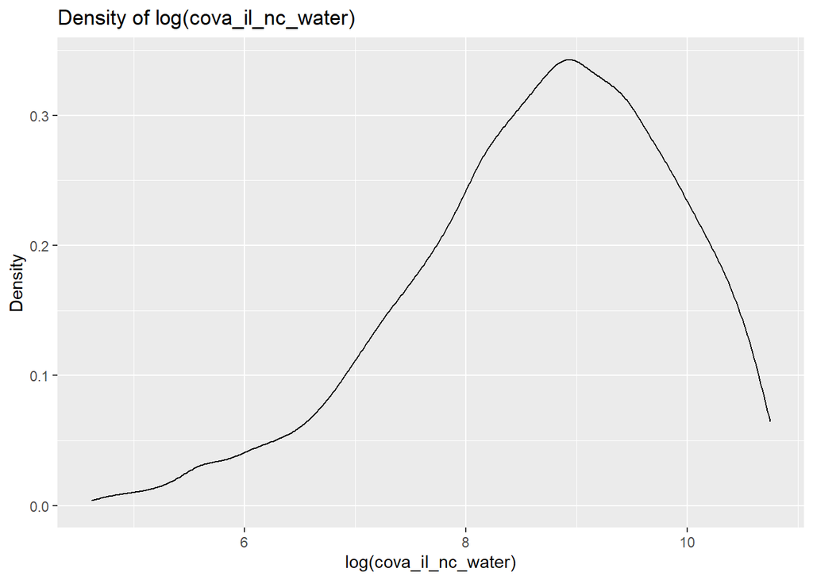

```r
ggplot(dataset, aes(x = .data[['log_cova_il_nc_water']])) +
  geom_density() +
  labs(x = 'log(cova_il_nc_water)', y = 'Density', title = 'Density of log(cova_il_nc_water)')
```

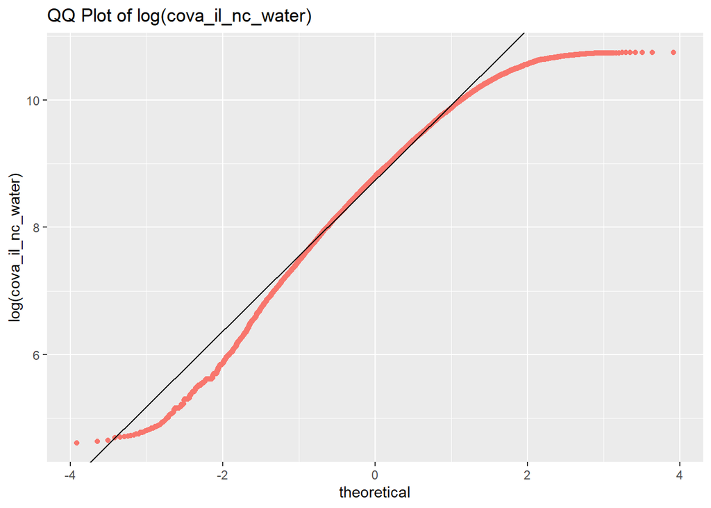

```r
  vec <- dataset$log_cova_il_nc_water
  y <- quantile(vec[!is.na(vec)], c(0.25, 0.75))
  x <- qnorm(c(0.25, 0.75))
  slope <- diff(y)/diff(x)
  int <- y[1L] - slope * x[1L]

ggplot(dataset, aes(sample = .data[['log_cova_il_nc_water']], col='red')) +
  stat_qq() +
  geom_abline(slope = slope, intercept = int) +
  theme(legend.position = "none") +
  labs(y = 'log(cova_il_nc_water)', title = 'QQ Plot of log(cova_il_nc_water)')
```

### Incurred Losses - Gamma Distribution

https://stackoverflow.com/questions/45536234/how-would-you-fit-a-gamma-distribution-to-a-data-in-r https://www.r-bloggers.com/goodness-of-fit-test-in-r/

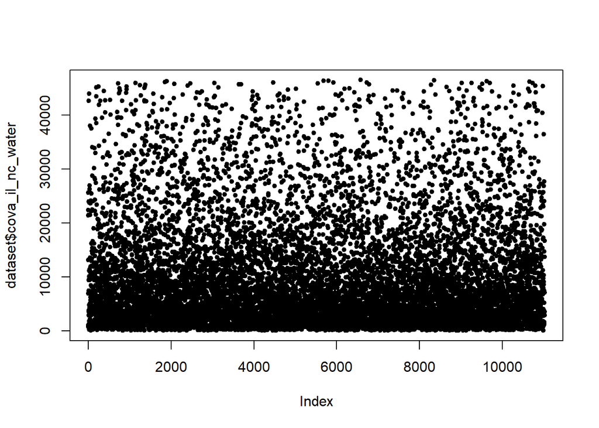

```r
plot(dataset$cova_il_nc_water, pch=20)
```

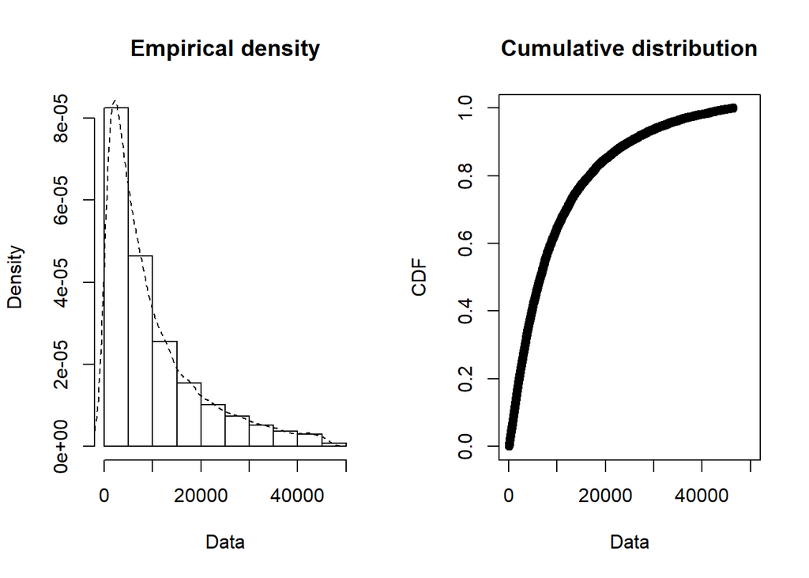

```r
plotdist(dataset$cova_il_nc_water, histo = TRUE, demp = TRUE)
```

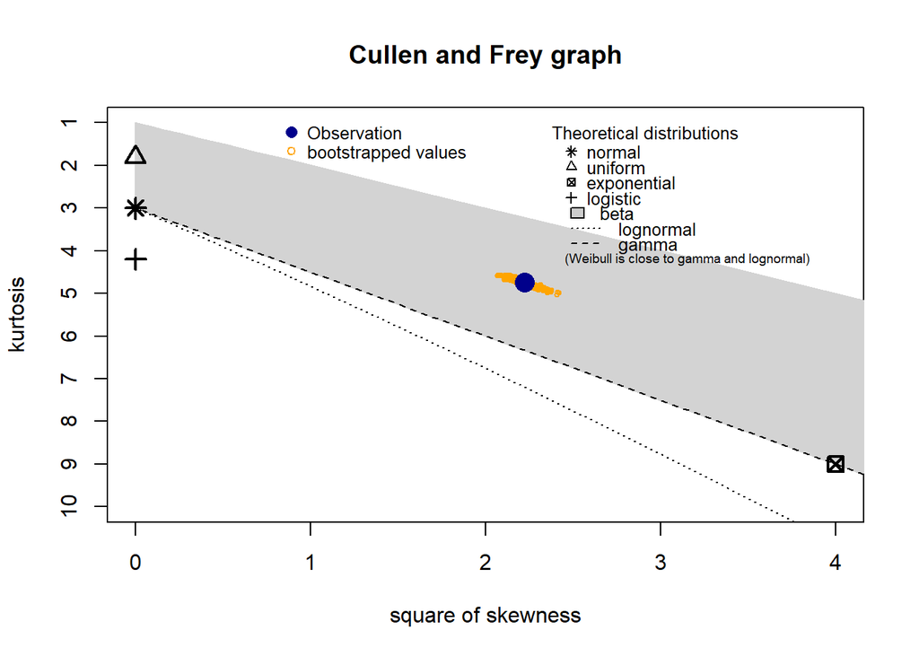

```
## summary statistics
## ------
## min:  101.16   max:  46478.7
## median:  6592.555
## mean:  10060.89
## estimated sd:  9921.511
## estimated skewness:  1.491259
## estimated kurtosis:  4.749601
```

```r
descdist(dataset$cova_il_nc_water, discrete=FALSE, boot=500)
```

Scaling is needed to preven “Error in fitdist(dataset$cova_il_nc_water/10,”gamma“, method =”mle“) : the function mle failed to estimate the parameters, with the error code 100”

https://stackoverflow.com/questions/53557022/error-code-100-fitting-exp-distribution-using-fitdist-in-r

It looks like some numerical stability problem with the underlying algorithm. It hits something indistinguishable from infinity.

```r
fit_w  <- fitdist(dataset$cova_il_nc_water/100, "weibull", method="mle")
fit_g  <- fitdist(dataset$cova_il_nc_water/100, "gamma", method="mle")
fit_ln <- fitdist(dataset$cova_il_nc_water/100, "lnorm", method="mle")
```

```r
summary(fit_w)
```

```
## Fitting of the distribution ' weibull ' by maximum likelihood
## Parameters :
##         estimate  Std. Error
## shape   1.013154 0.007503436
## scale 101.189548 1.004411260
## Loglikelihood:  -61834.32   AIC:  123672.6   BIC:  123687.2
## Correlation matrix:
##           shape     scale
## shape 1.0000000 0.3200784
## scale 0.3200784 1.0000000
```

```r
summary(fit_g)
```

```
## Fitting of the distribution ' gamma ' by maximum likelihood
## Parameters :
##         estimate   Std. Error
## shape 1.04059128 0.0122611408
## rate  0.01034088 0.0001534012
## Loglikelihood:  -61830.34   AIC:  123664.7   BIC:  123679.3
## Correlation matrix:
##           shape      rate
## shape 1.0000000 0.7817832
## rate  0.7817832 1.0000000
```

```r
summary(fit_ln)
```

```
## Fitting of the distribution ' lnorm ' by maximum likelihood
## Parameters :
##         estimate  Std. Error
## meanlog 4.059114 0.011257903
## sdlog   1.181812 0.007960514
## Loglikelihood:  -62209.01   AIC:  124422   BIC:  124436.6
## Correlation matrix:
##         meanlog sdlog
## meanlog       1     0
## sdlog         0     1
```

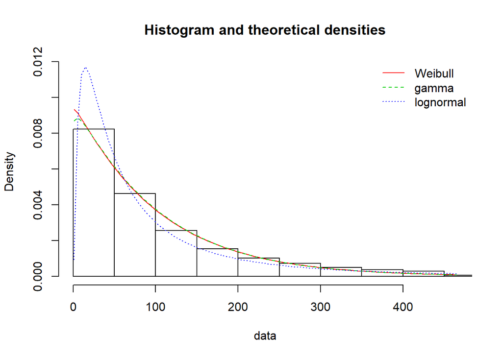

```r
plot.legend <- c("Weibull", "gamma", "lognormal")
denscomp(list(fit_w,  fit_g, fit_ln), legendtext = plot.legend)
```

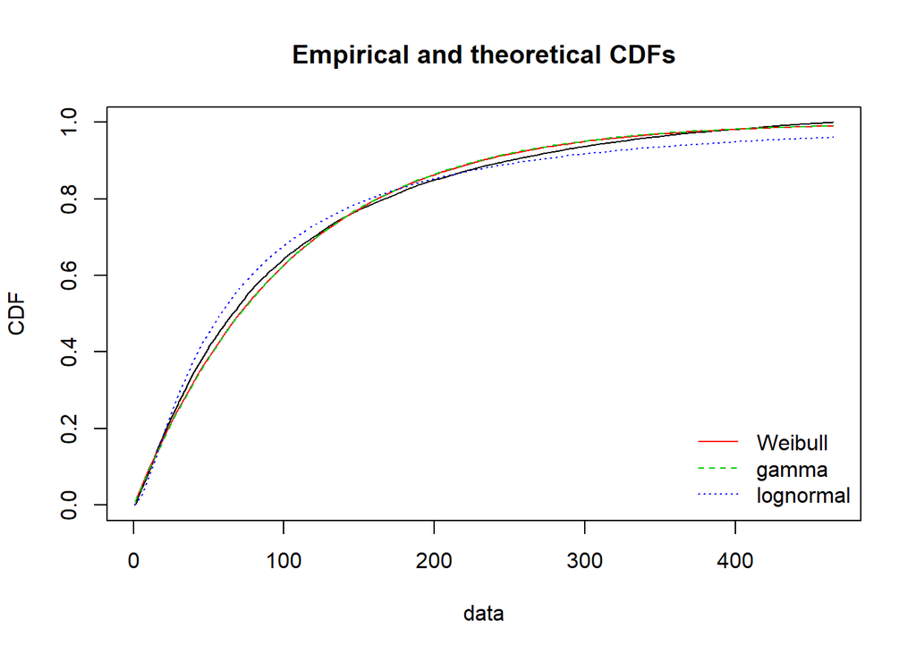

```r
cdfcomp (list(fit_w,  fit_g, fit_ln), legendtext = plot.legend)
```

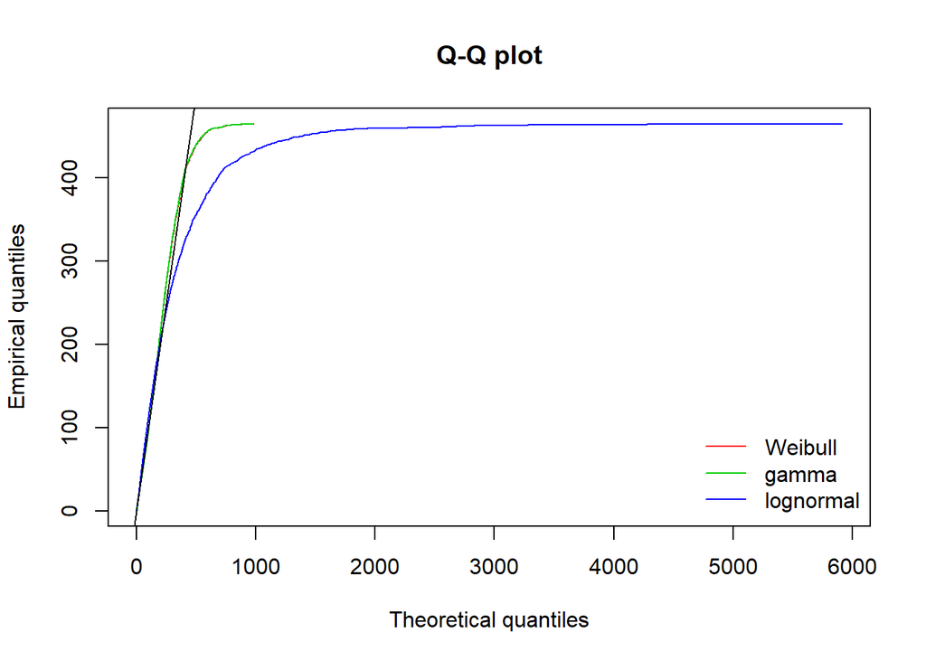

```r
qqcomp  (list(fit_w,  fit_g, fit_ln), legendtext = plot.legend)
```

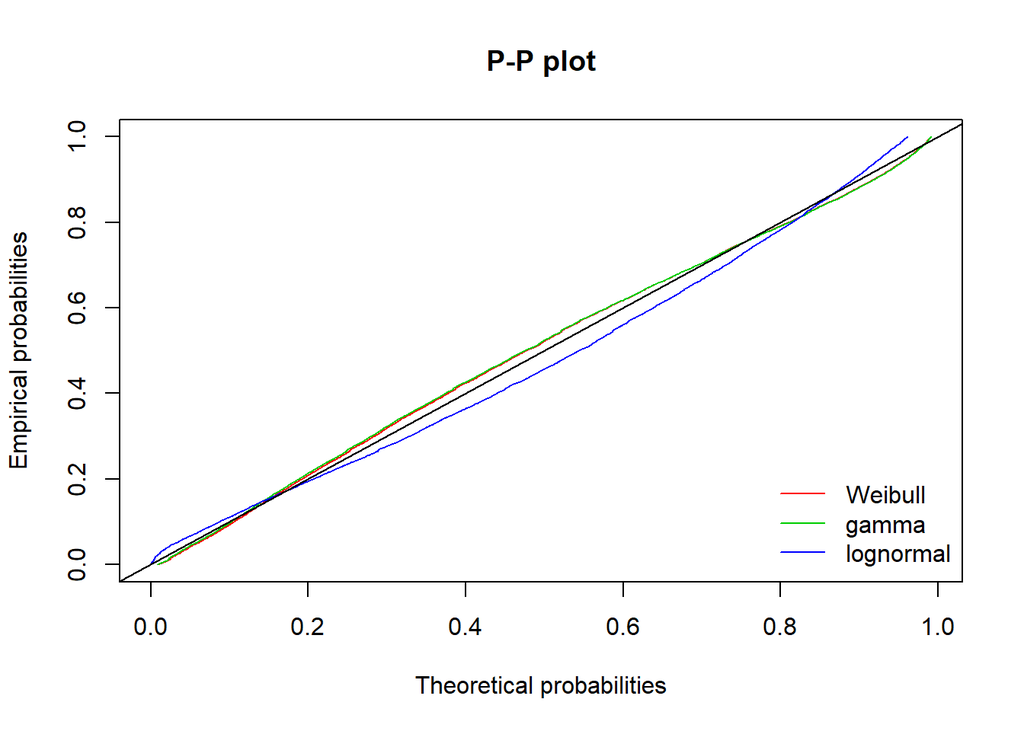

```r
ppcomp  (list(fit_w,  fit_g, fit_ln), legendtext = plot.legend)
```

Gamma and weibull are close to each other. The observed distribution is not good for any. Well, the best from worse is Gamma

#### Kolmogorov-Smirnov does not work

```r
m <- mean(dataset$cova_il_nc_water)
v <- var(dataset$cova_il_nc_water)

print(m)
```

```
## [1] 10060.89
```

```r
print(v)
```

```
## [1] 98436385
```

```r
scale <- v/m
shape <- m*m/v

print(shape)
```

```
## [1] 1.028293
```

```r
print(1/scale)
```

```
## [1] 0.000102207
```

Kolmogorov-Smirnov is simple nonparametric test for one dimensional probability distribution. Same as Cramer von Mises test, it compares empirical distribution with reference probability.

```r
num_of_samples = 10000
y <- rgamma(num_of_samples, shape = shape, scale = 1/scale)
ks.test(dataset$cova_il_nc_water, y)
```

```
##
##  Two-sample Kolmogorov-Smirnov test
##
## data:  dataset$cova_il_nc_water and y
## D = 1, p-value < 2.2e-16
## alternative hypothesis: two-sided
```

### Log of Incurred Losses - Normal Distribution

```r
dataset <- data[data$cova_il_nc_water>100,]
```

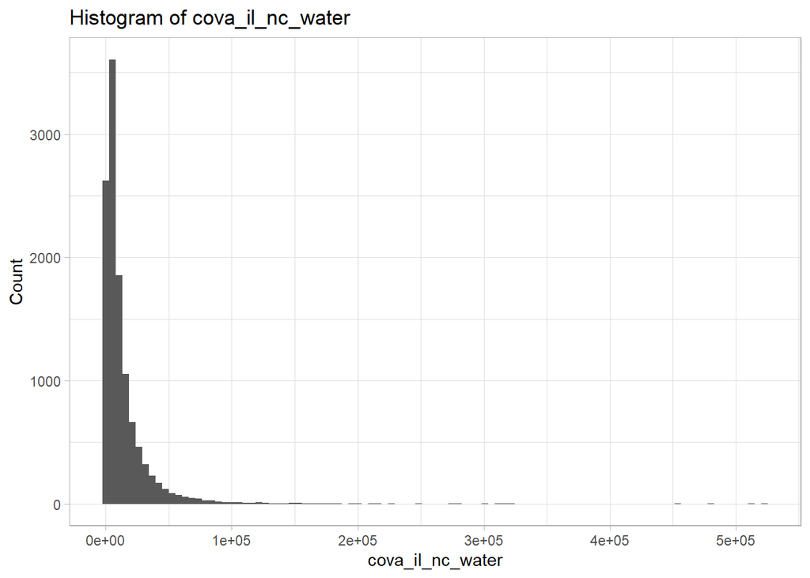

```r
ggplot(dataset, aes(x = .data[['cova_il_nc_water']])) +
  geom_histogram(bins=100) +
  labs(x = 'cova_il_nc_water', y = 'Count', title = paste("Histogram of", 'cova_il_nc_water'))+
  theme_light()
```

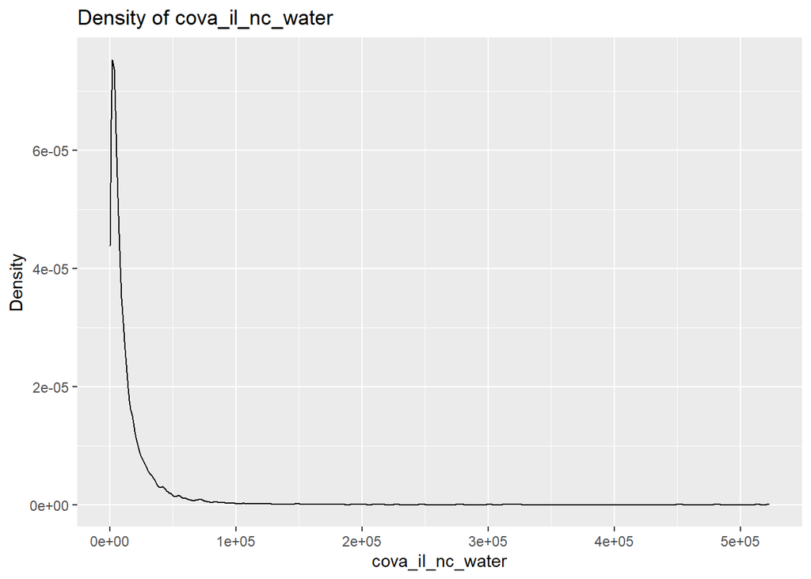

```r
ggplot(dataset, aes(x = .data[['cova_il_nc_water']])) +
  geom_density() +
  labs(x = 'cova_il_nc_water', y = 'Density', title = paste("Density of", 'cova_il_nc_water'))
```

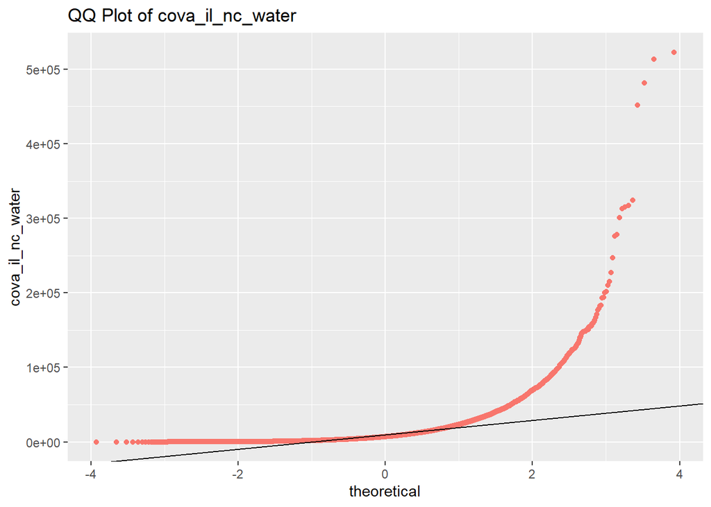

```r
  vec <- dataset$cova_il_nc_water
  y <- quantile(vec[!is.na(vec)], c(0.25, 0.75))
  x <- qnorm(c(0.25, 0.75))
  slope <- diff(y)/diff(x)
  int <- y[1L] - slope * x[1L]

ggplot(dataset, aes(sample = .data[['cova_il_nc_water']], col='red')) +
  stat_qq() +
  geom_abline(slope = slope, intercept = int) +
  theme(legend.position = "none") +
  labs(y = 'cova_il_nc_water', title = paste("QQ Plot of", 'cova_il_nc_water'))
```

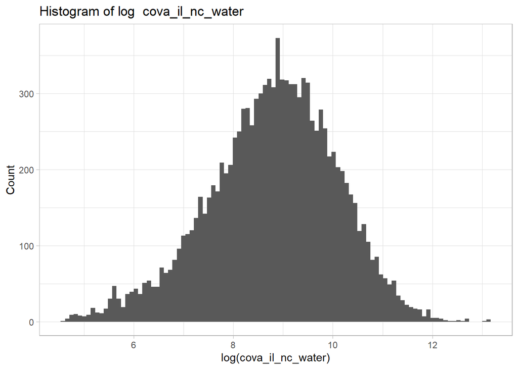

```r
ggplot(dataset, aes(x = .data[['log_cova_il_nc_water']])) +
  geom_histogram(bins=100) +
  labs(x = 'log(cova_il_nc_water)', y = 'Count', title = paste("Histogram of log ", 'cova_il_nc_water'))+
  theme_light()
```

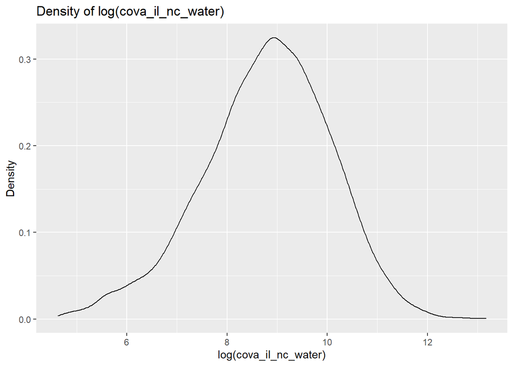

```r
ggplot(dataset, aes(x = .data[['log_cova_il_nc_water']])) +
  geom_density() +
  labs(x = 'log(cova_il_nc_water)', y = 'Density', title = 'Density of log(cova_il_nc_water)')
```

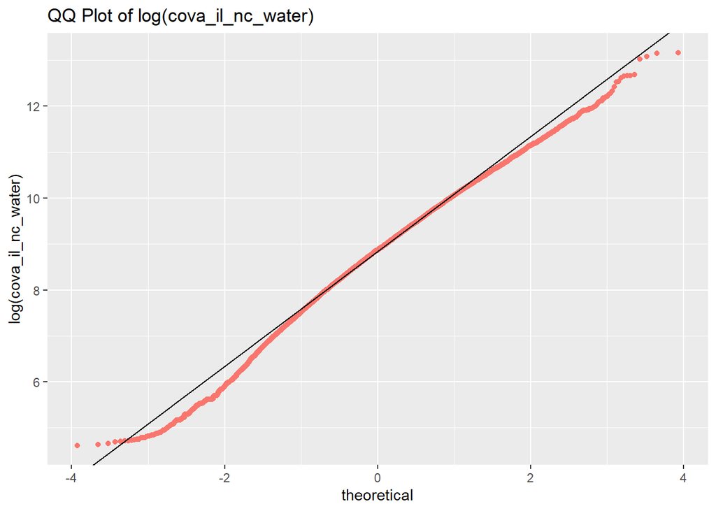

```r
  vec <- dataset$log_cova_il_nc_water
  y <- quantile(vec[!is.na(vec)], c(0.25, 0.75))
  x <- qnorm(c(0.25, 0.75))
  slope <- diff(y)/diff(x)
  int <- y[1L] - slope * x[1L]

ggplot(dataset, aes(sample = .data[['log_cova_il_nc_water']], col='red')) +
  stat_qq() +
  geom_abline(slope = slope, intercept = int) +
  theme(legend.position = "none") +
  labs(y = 'log(cova_il_nc_water)', title = 'QQ Plot of log(cova_il_nc_water)')
```

#### Shapiro test

```r
shapiro.test(dataset[sample(nrow(dataset), 5000), 'log_cova_il_nc_water'])
```

```
##
##  Shapiro-Wilk normality test
##
## data:  dataset[sample(nrow(dataset), 5000), "log_cova_il_nc_water"]
## W = 0.99235, p-value = 9.133e-16
```

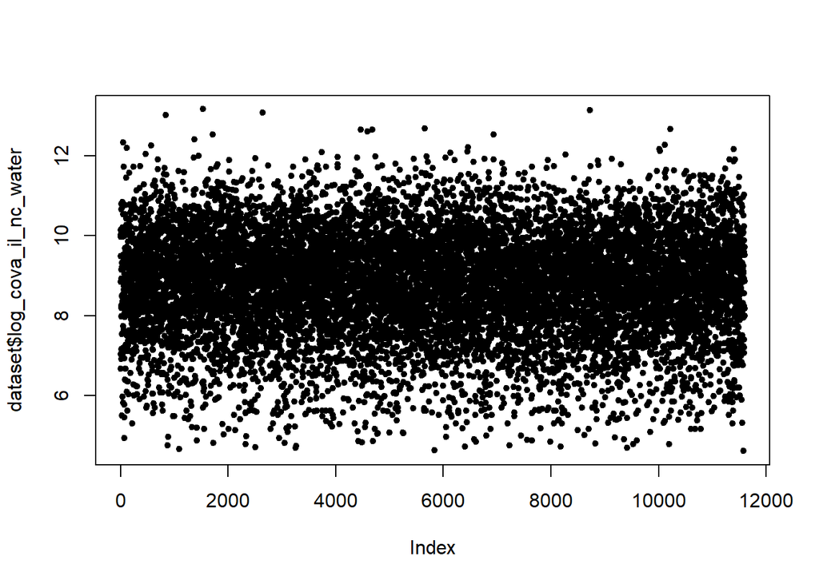

```r
plot(dataset$log_cova_il_nc_water, pch=20)
```

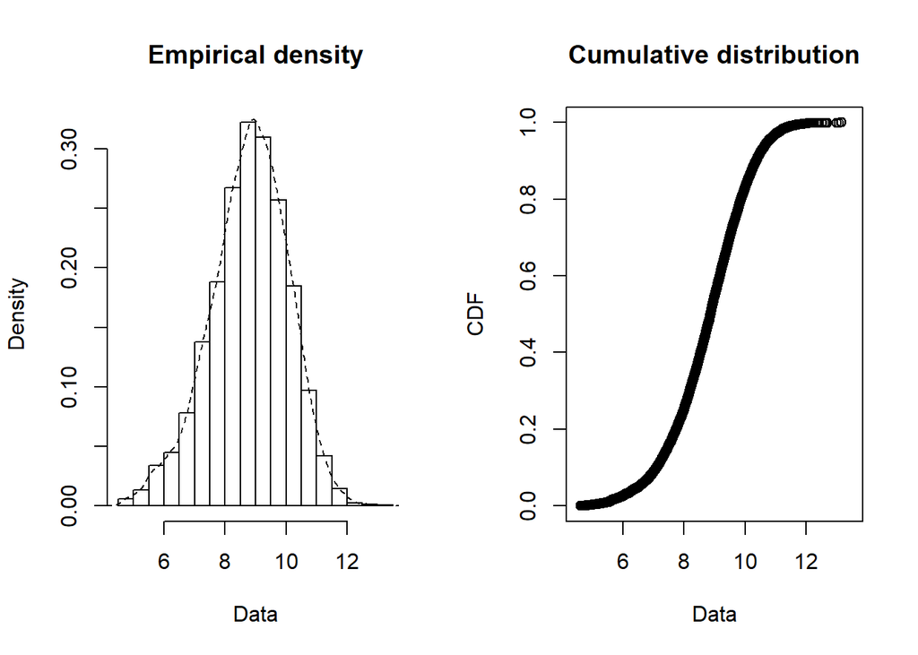

```r
plotdist(dataset$log_cova_il_nc_water, histo = TRUE, demp = TRUE)
```

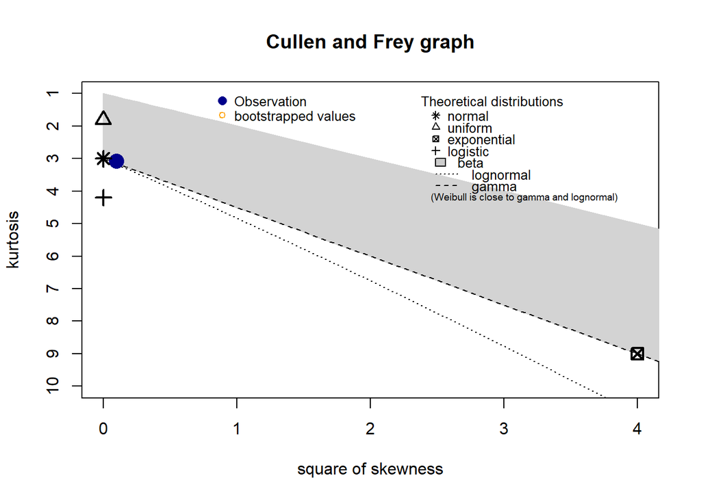

```
## summary statistics
## ------
## min:  4.616703   max:  13.16683
## median:  8.869405
## mean:  8.791553
## estimated sd:  1.281621
## estimated skewness:  -0.3127817
## estimated kurtosis:  3.078105
```

```r
descdist(dataset$log_cova_il_nc_water, discrete=FALSE, boot=500)
```

```r
fit_n  <- fitdist(dataset$log_cova_il_nc_water, "norm", method="mle")
```

```r
summary(fit_n)
```

```
## Fitting of the distribution ' norm ' by maximum likelihood
## Parameters :
##      estimate  Std. Error
## mean 8.791553 0.011898529
## sd   1.281566 0.008413507
## Loglikelihood:  -19339.11   AIC:  38682.23   BIC:  38696.95
## Correlation matrix:
##      mean sd
## mean    1  0
## sd      0  1
```

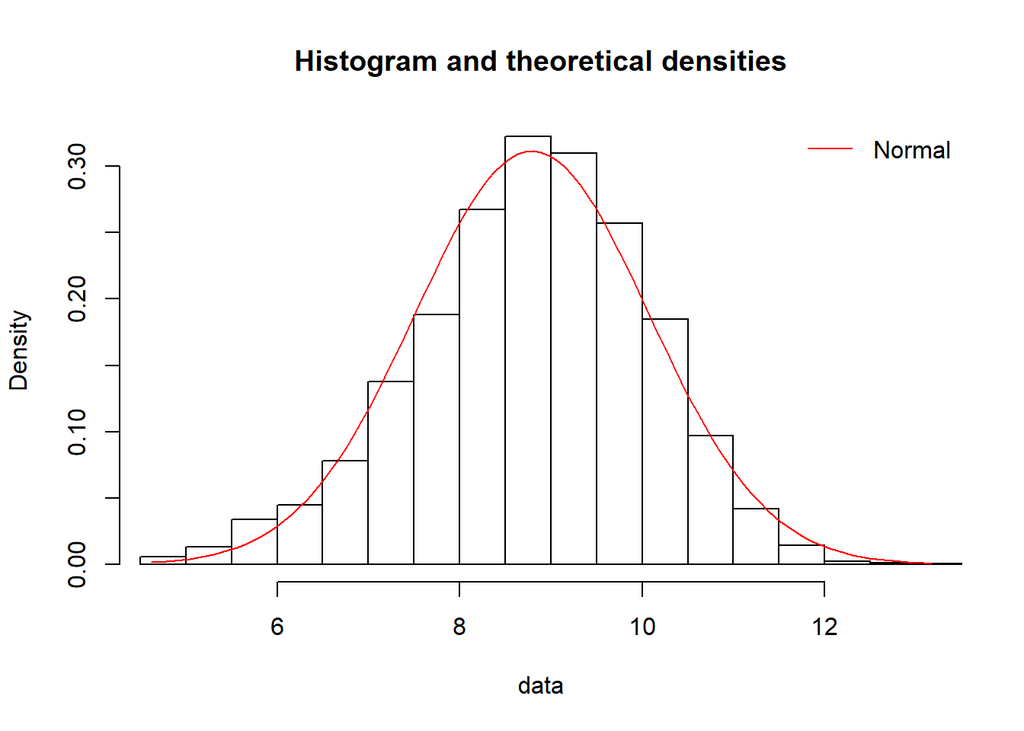

```r
plot.legend <- c("Normal")
denscomp(list(fit_n), legendtext = plot.legend)
```

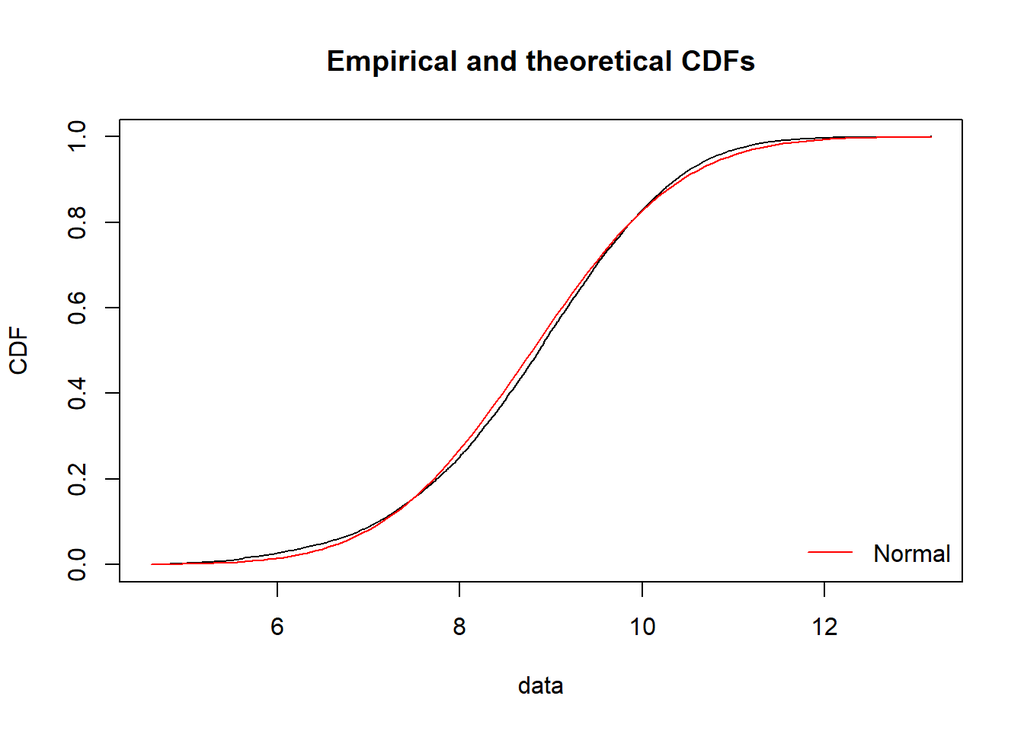

```r
cdfcomp (list(fit_n), legendtext = plot.legend)
```